# Групповой проект номер №5

Дисциплина “Научное программирование”

Супонина Анастасия Павловна,

Лобов Михаил Сергеевич,

Нирдоши Всеволод Раджендер

Кафедра теории вероятностей и кибербезопасности

Российский университет дружбы народов имени Патриса Лумумбы, Москва, Россия

02 Ноября 2024

## Задача о эпидемии

Задача о эпидемии — это математическая модель, описывающая распространение инфекционных заболеваний в популяции.

Моделирование эпидемий важно для:  
- прогнозирования инфекций  
- разработки стратегий вакцинации  
- контроля распространения болезней

## Модель

Модель динамики эпидемии базируется на системе дифференциальных уравнений, которая описывает скорость изменения численности этих трёх групп.  
Для исследования этой задчи используют разные модели. Мы будем исспользовать модель SIR.

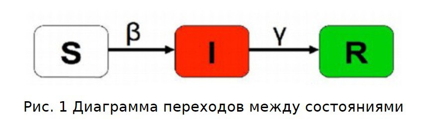

В нашей задаче дополнительным условием является значение crit_I, которое отображает критическое количество зараженных, при котором если I>crit_I, то эпидемия распространяется.

## Библиотека `DifferentialEquations.jl`

Julia предоставляет мощную библиотеку для решения обыкновенных дифференциальных уравнений (ODE) с помощью `DifferentialEquations.jl`. С помощью функции `ODEProblem` можно задать дифференциальное уравнение, начальные условия и временной промежуток для решения. Использование этой библиотеки позволят нам избежать того, что мы решаем не просто дифференциальные уравнения, а алгебродифференциальные уравнения, таким образом при решении задачи таким методом, число людей в нашей ограниченной популяции всегда остается одинаковым.

```julia
import Pkg
Pkg.add("DifferentialEquations")

prob_combo = ODEProblem(combo_case!, u0, tspan, p_combo)
```

## Библиотеки `Plots`

Для построения графиков используем библиотеку `Plots`. Решение можно легко визуализировать на графике, чтобы увидеть, как изменяются популяции во времени (например, восприимчивые, зараженные, выздоровевшие).

```julia
import Pkg
Pkg.add("Plots")

sol_combo = solve(prob_combo)
plot(sol_combo, title="Комбинированная фаза: с учетом критического
порога", label=["S" "I" "R"])
```

## Параметры задачи

```julia
N = 7777  # Общее количество особей в популяции
# Она делится на 3 группы (по обозначениям SIR) :
I = 700   # Количество инфицированных особей
R = 0     # Количество выздоровевших особей
S = N - I - R  # Количество здоровых, восприимчивых к инфекции особей
# В дифференциальных уравнениях модели у нас появляются два коэффициента:
a = 0.007  # Коэффициент заболевания
b = 0.003  # Коэффициент выздоровления
# Если I < crit_I, то все больные изолированы.
crit_I = 90 # Критическое значение инфицированных
# Начальные условия
u0 = [S, I, R]
tspan = (0.0, 2500.0)
```

## Первый случай

**Всех заболевших получилось изолировать ( I(t) ≤ I* ).**

```julia
# Определение первой фазы, где происходит только выздоровление
function first_case!(du, u, p, t)
    _, b = p
    du[1] = -u[1] * b  # Уменьшается за счет выздоровления
    du[2] = u[1] * b   # Увеличивается
end
```

## Первый случай

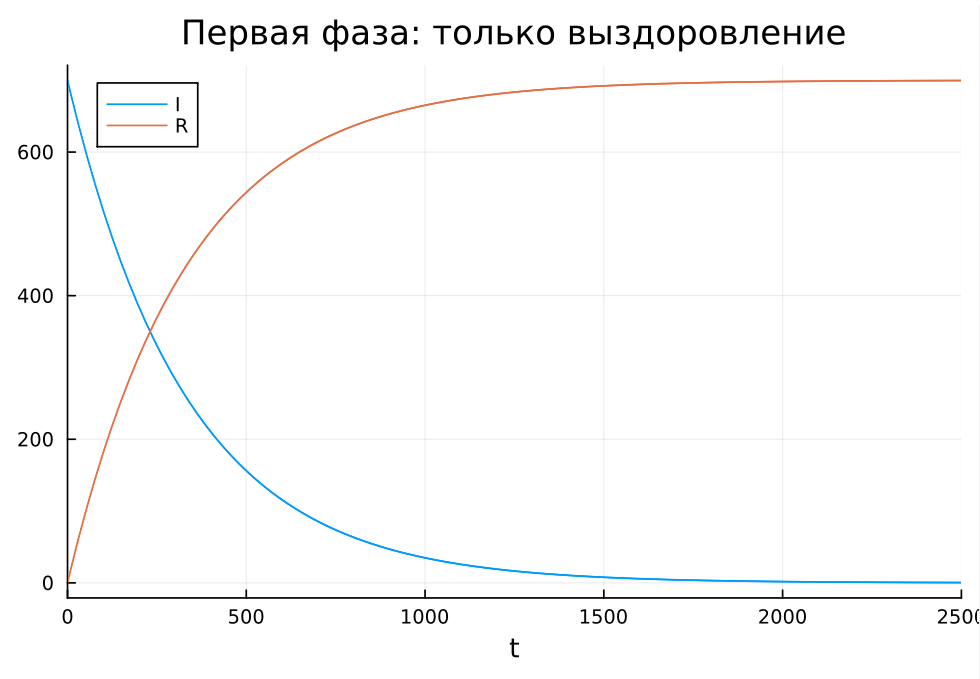

## Второй случай

**Всех заболевших НЕ получилось изолировать (I(t) > I* ).**

```julia
# Определение второй фазы, где происходят как заражения, так и выздоровления
function second_case!(du, u, p, t)
    a, b = p
    du[1] = -a * u[1]              # Уменьшается за счет заражений
    du[2] = a * u[1] - u[2] * b     # Изменяется из-за заражений и
    #выздоровлений
    du[3] = u[2] * b               # Увеличивается
end
```

## Второй случай

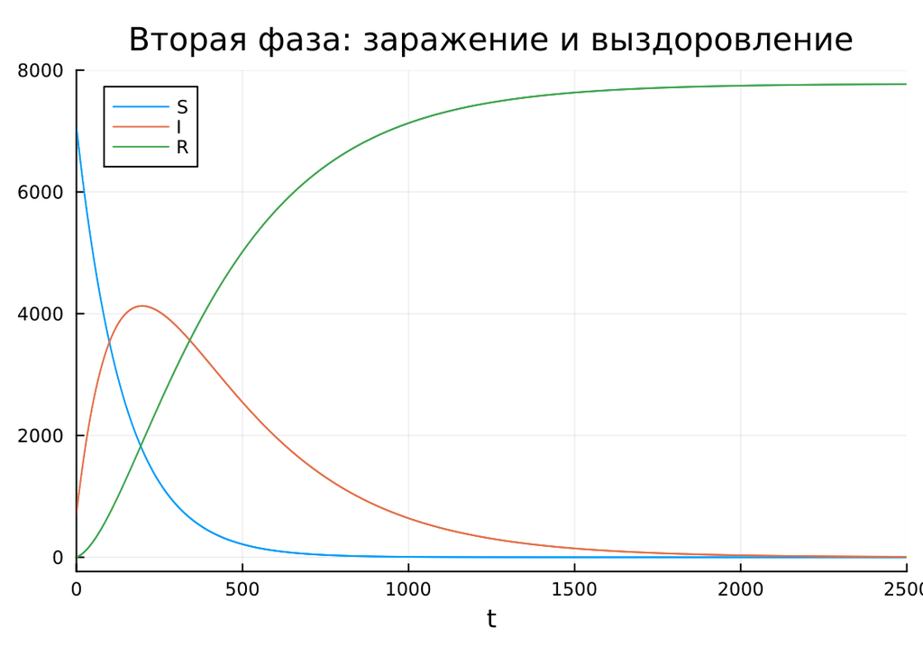

## Объединенное решение

```julia
# Определение комбинированной фазы с учетом критического порога
function combo_case!(du, u, p, t)
    a, b, crit_I = p
    if u[2] > crit_I
        du[1] = -a * u[1]          # Уменьшается за счет заражений
        du[2] = a * u[1] - u[2] * b
        du[3] = u[2] * b
    else
        du[1] = 0                  # Остается неизменным
        du[2] = -u[2] * b
        du[3] = u[2] * b
    end
end
```

## Объединенное решение

[figure not shown]

Спасибо за внимание!